# Height Diameter Models

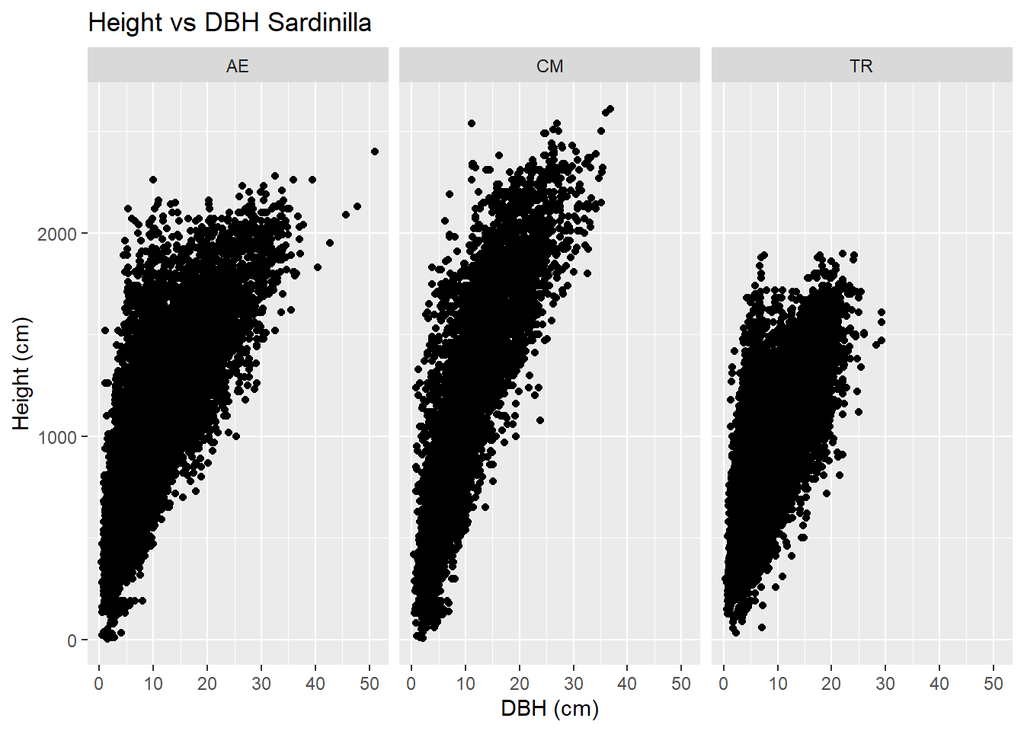

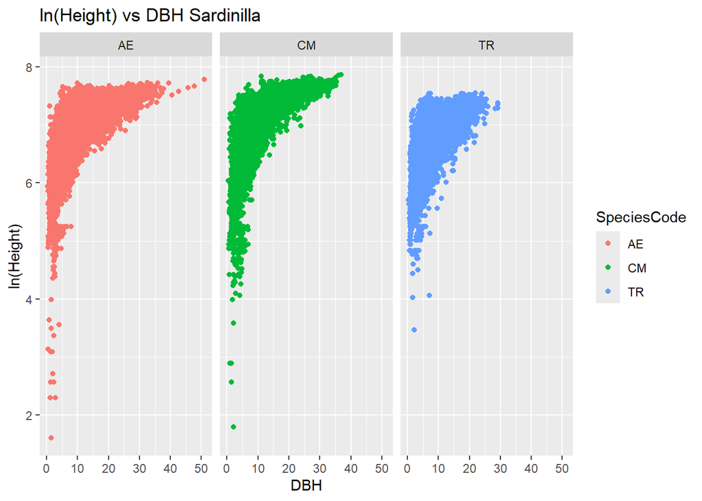

Using Basal Diameter:

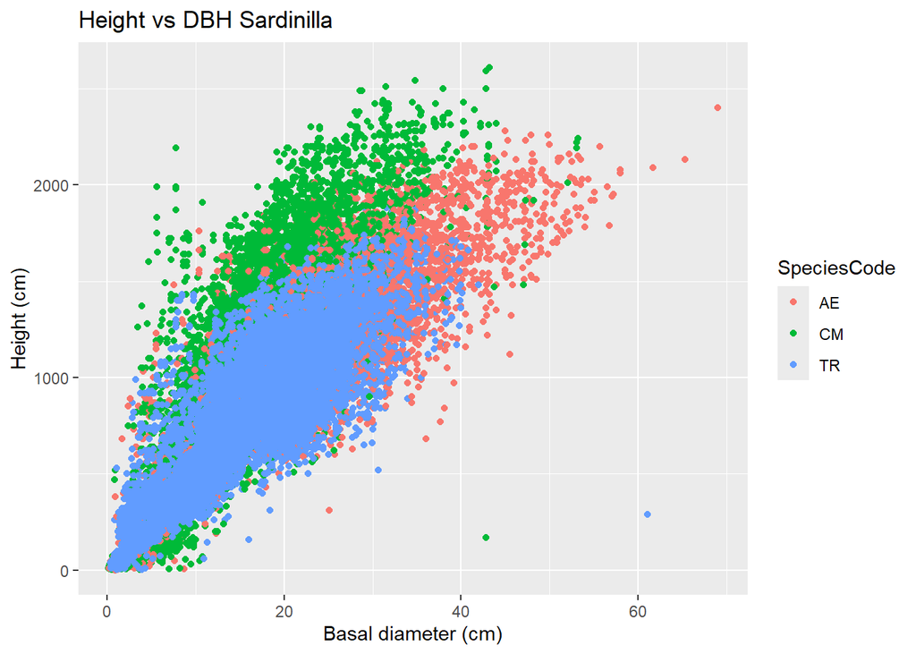

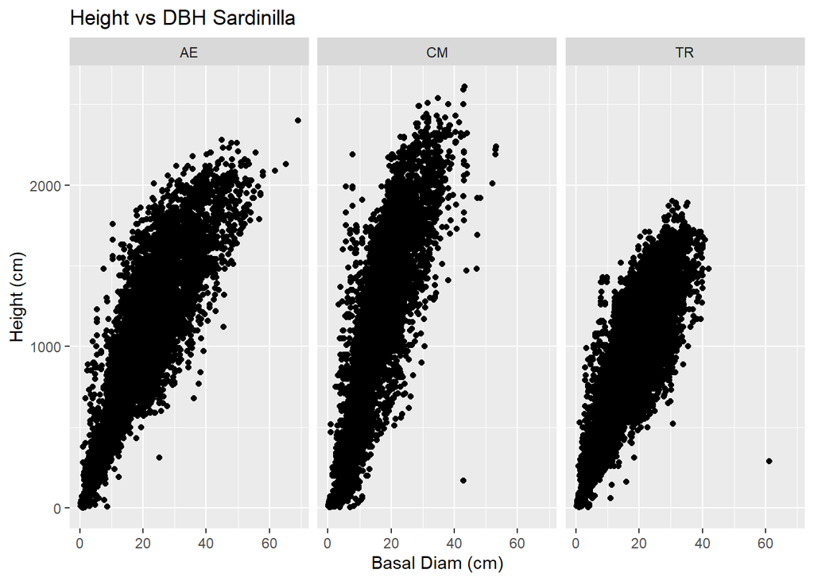

### SUMMARY

The clearest pattern is seen in ln(height) vs DBH.

## Testing Regressions

### Chave’s Equation (as a comparaison)

```r
chaveTest <- function(D) {
  lH <- 0.893 + 0.02418293 + 0.760*log(D) - 0.0340*((log(D))^2)
  # chaves equation gives height in in m
  return(lH)
}
```

### a: all species, DBH, Linear Height DBH regression

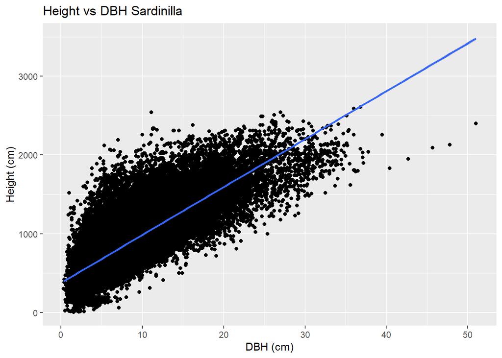

```r
s_data %>%
  select(SpeciesCode, Height, DBH)%>%
  drop_na() %>%
  ggplot(aes(x = DBH, y = Height)) +
  geom_point()+
  geom_smooth(method = "lm")+
  xlab("DBH (cm)") +
  ylab("Height (cm)") +
  ggtitle("Height vs DBH Sardinilla")
```

### b:Each species, DBH, Linear Height DBH regression

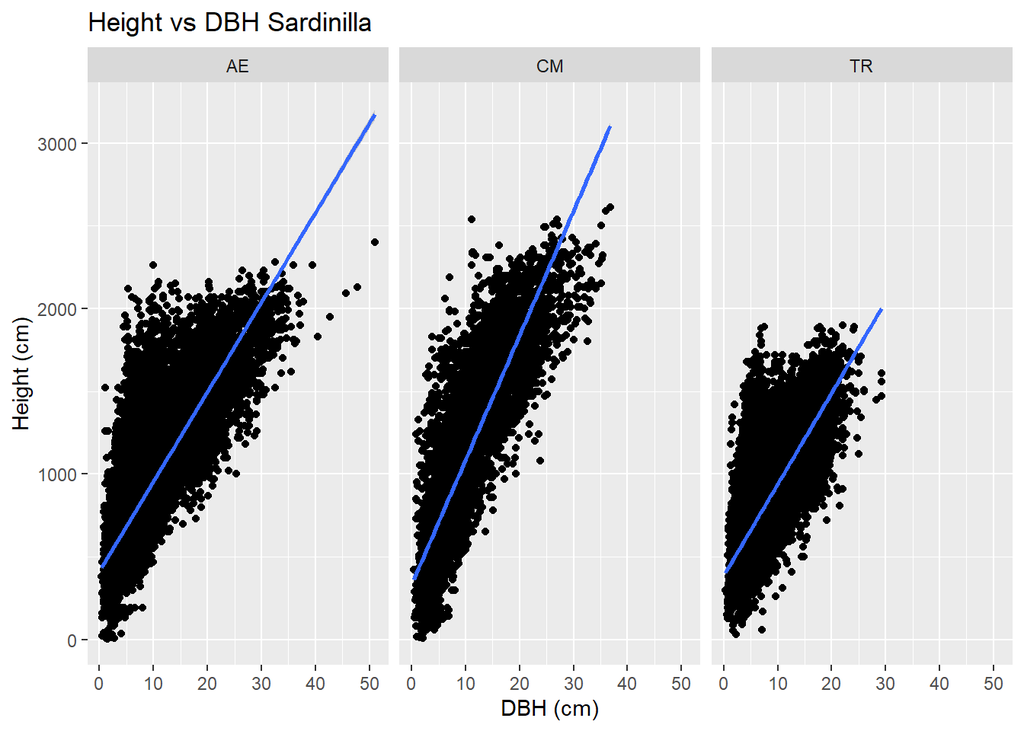

```r
s_data %>%
  select(SpeciesCode, Height, DBH)%>%
  drop_na() %>%
  ggplot(aes(x = DBH, y = Height)) +
  geom_point()+
  geom_smooth(method = "lm")+
  facet_grid(cols= vars(SpeciesCode)) +
  xlab("DBH (cm)") +
  ylab("Height (cm)") +
  ggtitle("Height vs DBH Sardinilla")
```

### c: all species, DBH, Quadratic - fit a quadratic lm for log(height)-diameter

```r
s_data$DBH2 <- s_data$DBH^2
glm1 <- lm(log(Height)~DBH+DBH2, data = s_data)
```

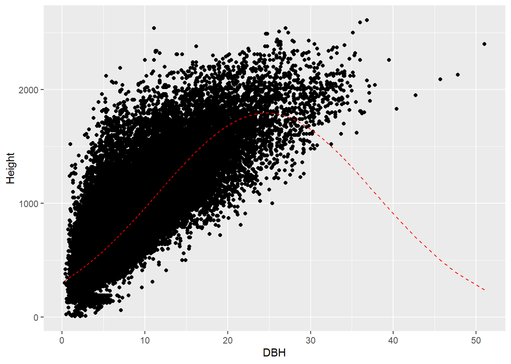

Doesn’t work: parabola falls off

### d: all species, DBH, fit lm for log(height)-log(diameter)

This model is the CURRENT BEST

```r
s_data$lDBH <- log(s_data$DBH)
s_data$lDBH2 <- s_data$lDBH^2
#quadratic
glm2q <- lm(log(Height)~lDBH + lDBH2, data = s_data)
#linear
glm2l <- lm(log(Height)~lDBH, data = s_data)
```

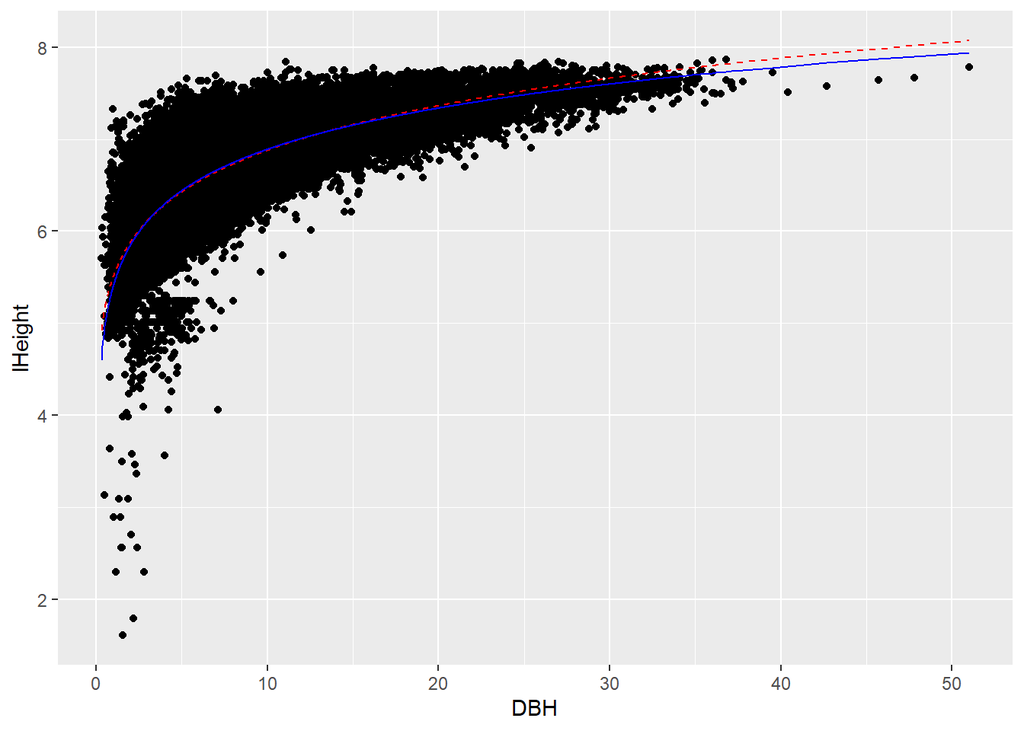

```r
#best - glm2l
glm2 <- lm(log(Height)~lDBH, data = s_data) # Equivalent to glm2l
```

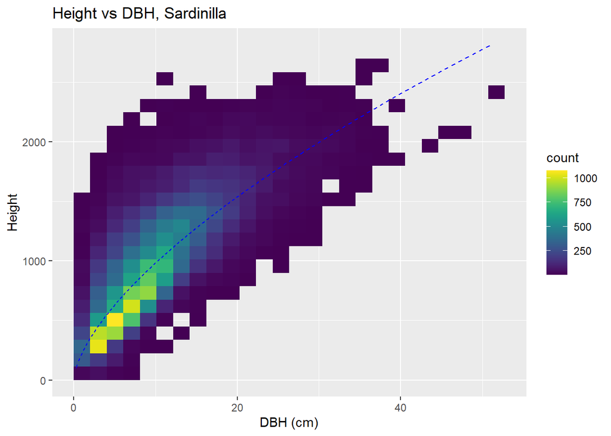

### e: all species, DBH, fit a lm for log(height)- diameter

```r
glm3 <- lm(log(Height) ~ DBH, data = s_data)
```

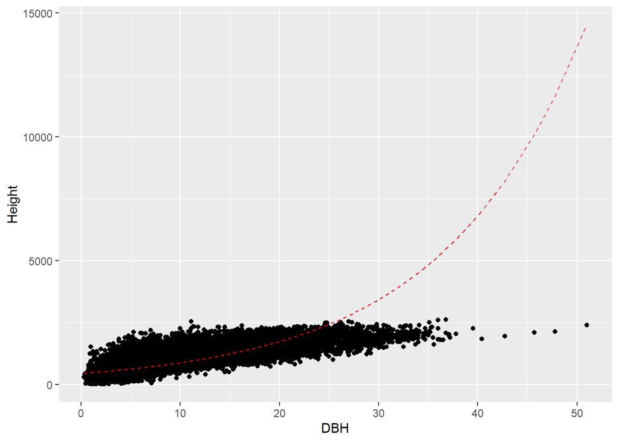

### f: separate species, DBH, fit linear lm for log(height)-log(diameter)

```r
#linear
TR.dat <- s_data %>%
  select(SpeciesCode, Height, lDBH) %>%
  filter(SpeciesCode == "TR") %>%
  drop_na()
glm2.TR <- lm(log(Height)~lDBH, TR.dat)
CM.dat <- s_data %>%
  select(SpeciesCode, Height, lDBH) %>%
  filter(SpeciesCode == "CM") %>%
  drop_na()
glm2.CM <- lm(log(Height)~lDBH, CM.dat)
AE.dat <- s_data %>%
  select(SpeciesCode, Height, lDBH) %>%
  filter(SpeciesCode == "AE") %>%
  drop_na()
glm2.AE <- lm(log(Height)~lDBH, AE.dat)
```

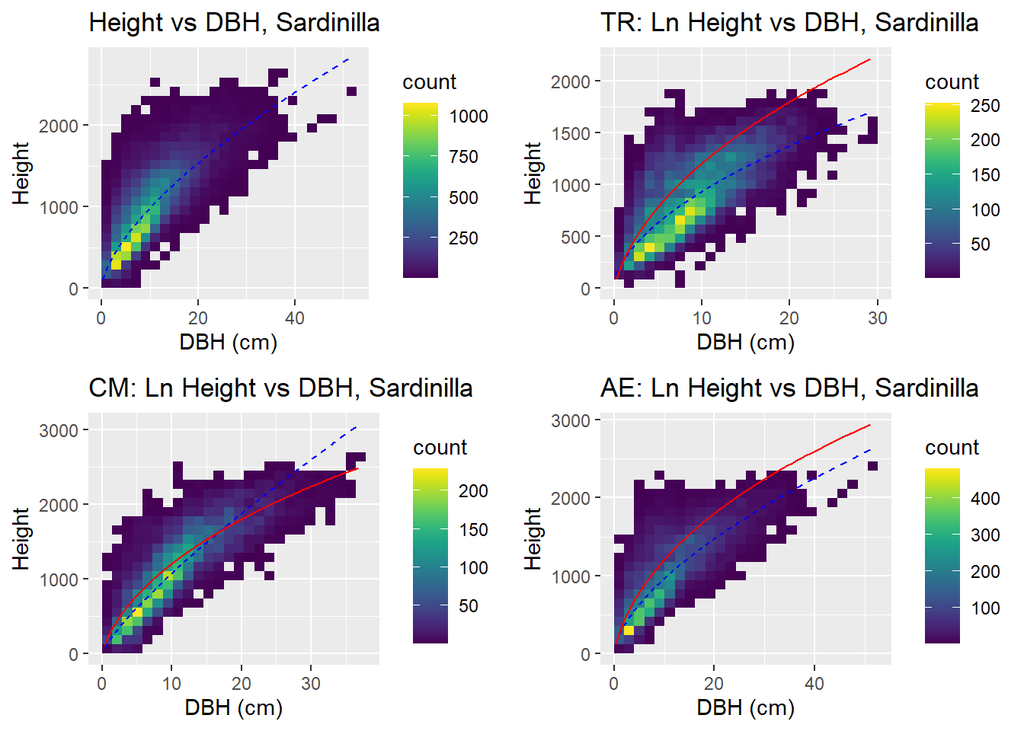

### SUMMARY:

1. Height- DBH All Species best: GLM2 lHeight ~ lDBH
2. Height-DBH Different species Use same model: GLM2 lHeight ~ lDBH

## Testing Equations

```r
glm2Test <- function(D) {
  lH <- 5.4015 + 0.642*log(D)
  return(lH)
}

glm2_iTest <- function(D) {
  lH <- 4.9476 + 0.6902*log(D)
  return(lH)
}
```

## Testing GLM2 on Sardinilla data

$Log(H) = 5.4015 + 0.642*Log(D)$

$H = e^{(5.4015 + 0.642*Log(D))}$

TEST SET:

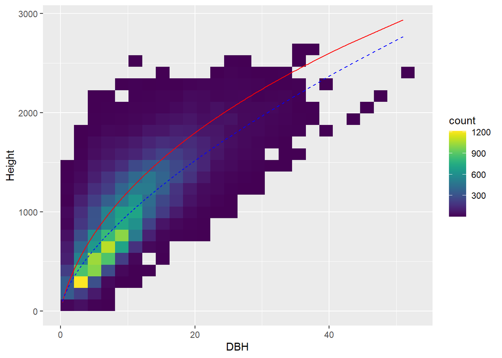

```r
df_t$lHeight <- log(df_t$Height)
```

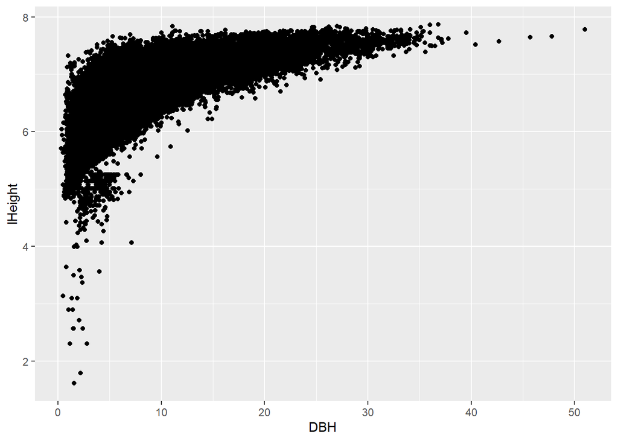

# Ipeti data

### Visualizing height - DBH

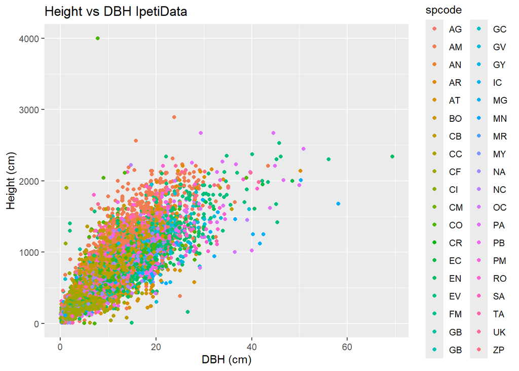

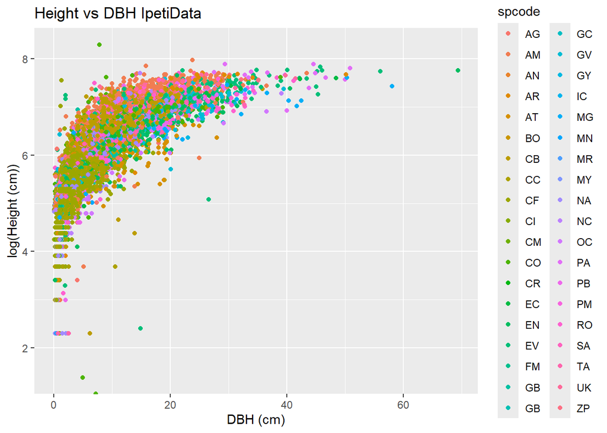

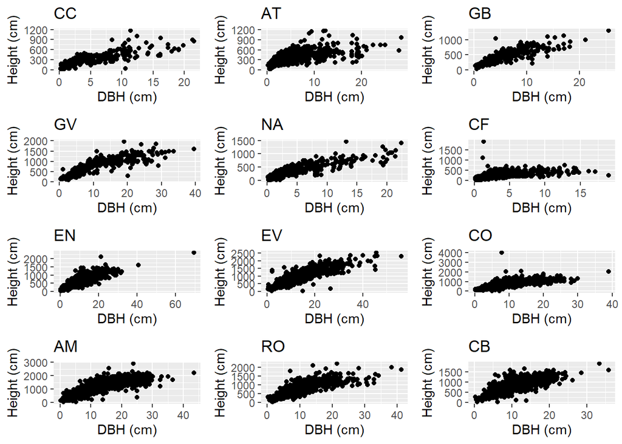

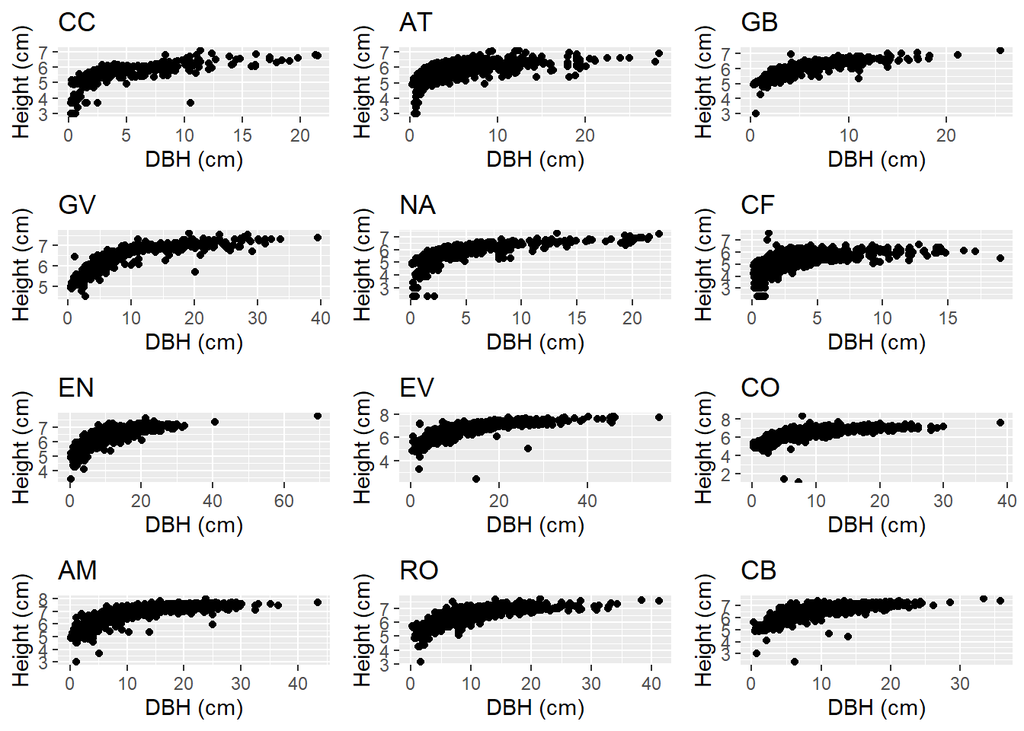

## Fitting Chave, Model on Ipeti Data

```r
i_data$glm2.lheight <- glm2Test(i_data$dbh)
i_data$glm2.height <- exp(i_data$glm2.lheight)
i_data$chave.lheight <- chaveTest(i_data$dbh)
i_data$chave.height <- exp(i_data$chave.lheight)*100 #was in m
```

Using normal data

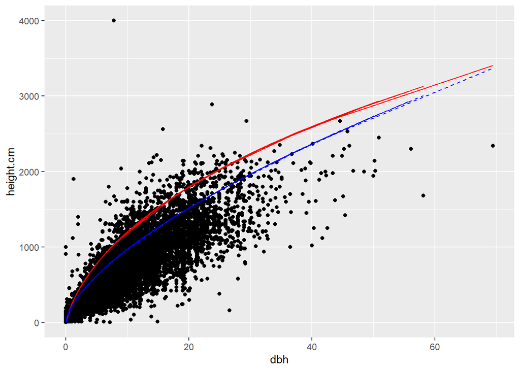

Data with density of points

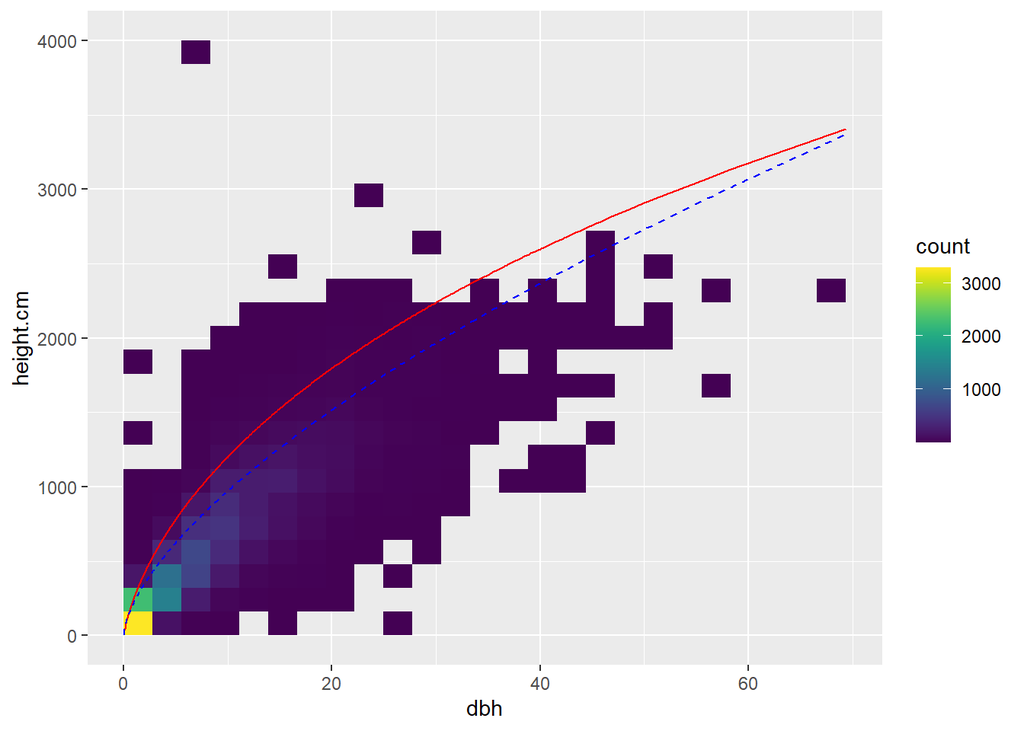